# Incareceration Across Races

Joey Yeo

2/25

### 1 Introduction:

The question we analyzed was what are the main defining characteristics of white incarceration rates vs black incarceration rates. We will investigate various hypotheses, for instance how the rates of African American and Caucasian populations differ over the years, and how incarceration rates varied by state. The 6 main variables we will be analyzing are “black_jail_pop”, “white_jail_pop”, “total_jail_pop”, “black_prison_pop”, “white_prison_pop”, and “total_prison_pop”. The reasoning behind the analysis of these variables is we would like to see how the white jail population and black jail population compare to the total jail population and the same with the prison data. This way we can discover any discirmination on a local level(jail) and a state or federal level(prison).

### 1.A Where are maximums of the main Variables in the most recent year?

Here, we investigate how the population of black people and white people compare in both prison and jail during the most recent year. We will introduce another comparison, the proportions to the general population.

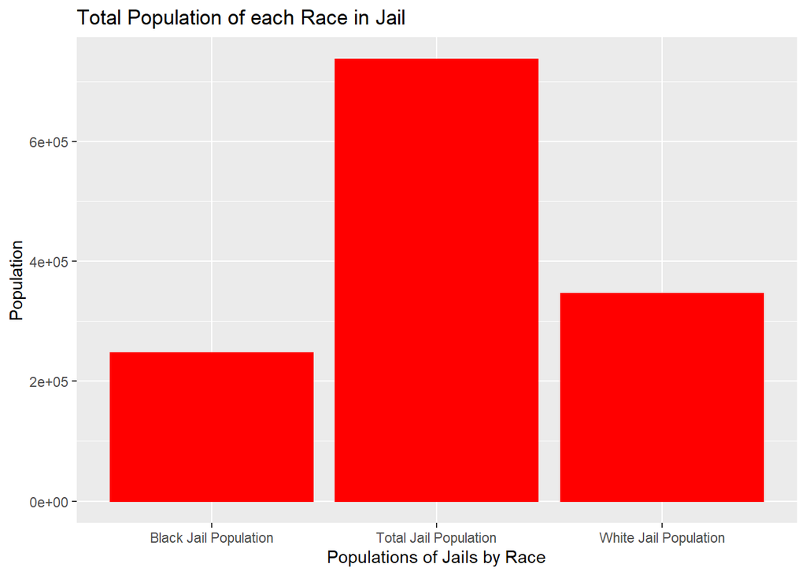

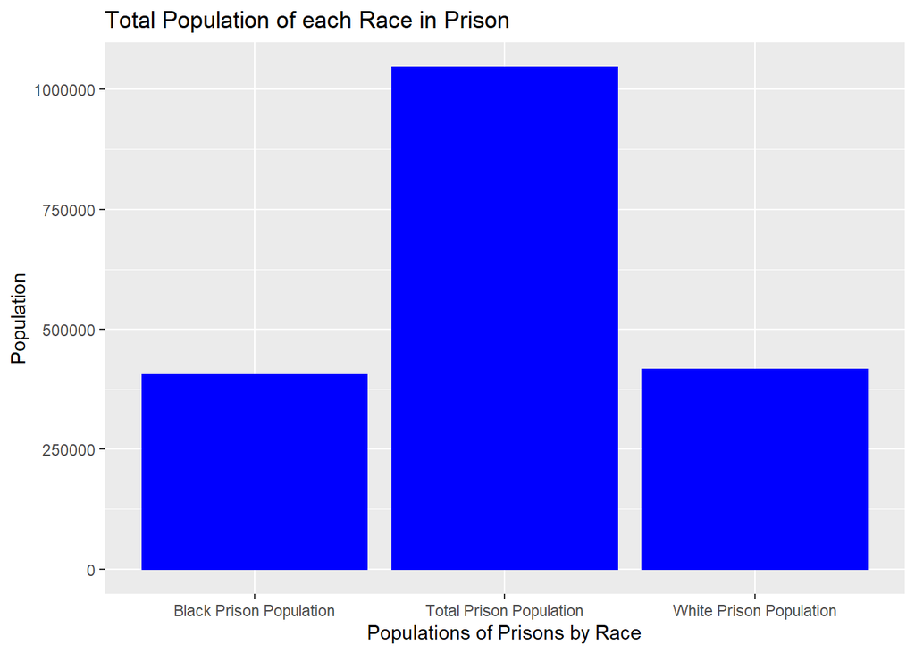

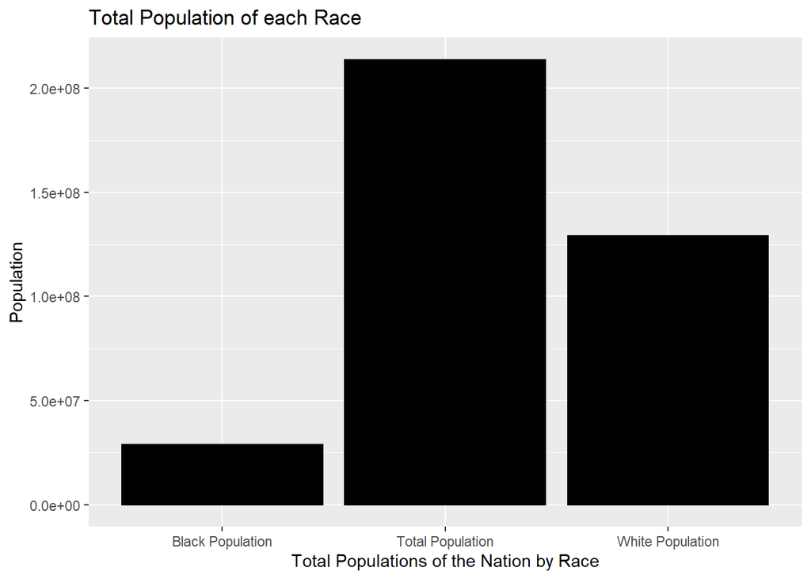

Looking at the charts above, it is clear that the total population of black people is significantly less than white people. The black population makes up very small amount of the total population of the nation. We see that the black population is 13.4835022% of the Nation’s total population but makes up for 33.5827154% in jails and 38.7336577% in prisons. While the white population makes up 60.3208577% of the Nation’s total population but makes up for 46.9474306% in jails and 39.7477179% in prisons. The black population makes a higher percentage of prisons and jails than it does to the national population, while the white population does the opposite.

### Populations of Jail and Prison Over Time

Here, we investigate how the population of black people and white people compare in both prison and jail over time. We will graph the comparisons on a line graph.

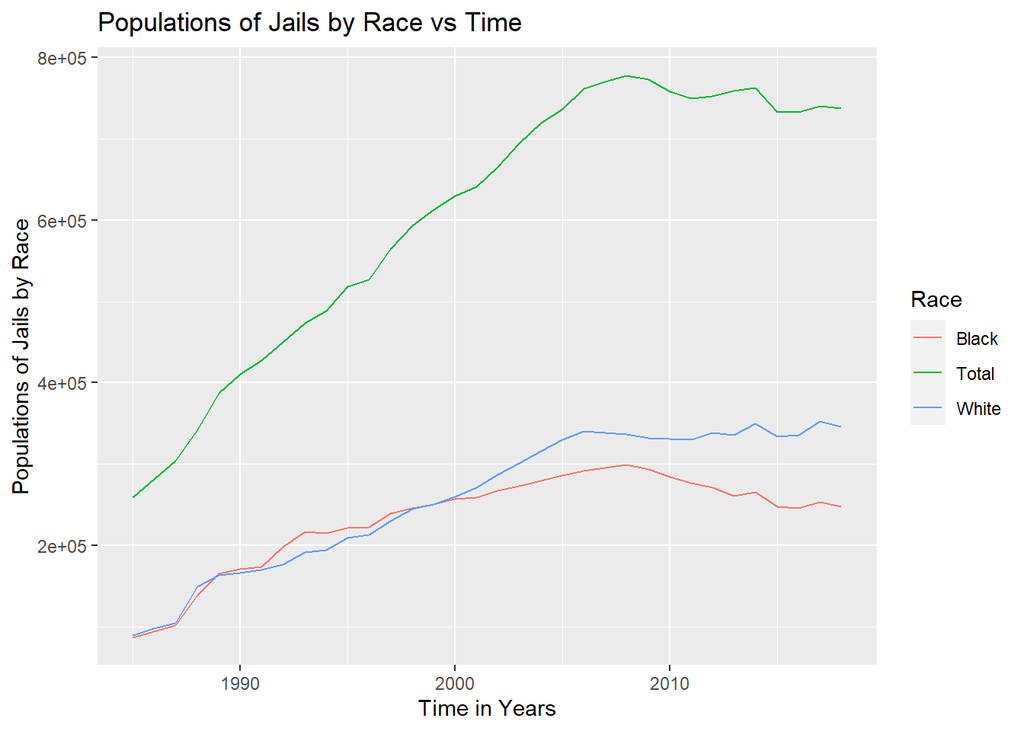

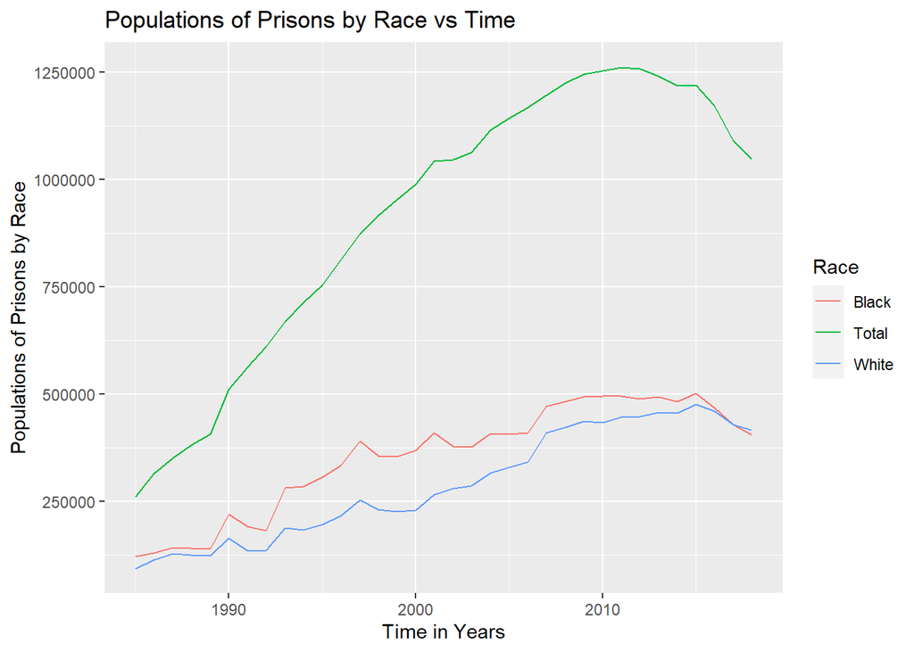

### Map

**African American Jail Population Density Map Across The United States of America**:

[interactive chart not shown]

It is very clear that there is a trend of more African Americans sent to jail the further south you go. Even though we cannot make any conclusions on the cause of this without further analysis. One thought would be to analyze the voting patterns for each state and analyze if there could be a possible trend with political party affiliation.